# Introduction: fitting a multilevel hidden Markov model

You can use your preferred way of working in R to do the practicals. Our preferred way is this:

- Create a new folder with a good name, e.g., `practicals_mHMM`
- Open RStudio
- Create a new project from RStudio, which you associate with the folder
- Create a `raw_data` subfolder
- Create an R script for the current practical, e.g., `introduction.R`
- Create your well-documented and [well-styled](https://style.tidyverse.org/) code in this R script

The answers to the practicals are available in the `*_answers.html` files. Try to work out the answer yourself (e.g., inpsecting help files and examples in the help files provided in the `mHMMbayes` package, looking at the tutorial vignette available online) before looking at this!

In all practicals in this workshop, we make use of the `mHMMbayes` package. You can load the package like

```r
library(mHMMbayes)
```

In this practical, we will also use the following packages:

```r
library(ggplot2)
```

## The data

We will use an open access dataset from Rowland and Wenzel (2020), available on OSF [`here`](https://osf.io/jmz2n/). The data consists of one-hundred twenty-five undergraduate students from the University of Mainz in Germany that completed a 40-day ambulatory assessment six times a day, reporting on their affective experiences *happy*, *excited*, *relaxed*, *satisfied*, *angry*, *anxious*, *depressed*, and *sad*. These items were scored with a visual analog slider from 0 to 100. Before the collection of the ESM measurements, participants of the study were randomly assigned to a group receiving a weekly mindfulness treatment during the ESM study and a control group. A cleaned version of the data kindly provided in the data archive as part of Haslbeck, Ryan, & Dablander (2023), the repository can be found [`here`](https://github.com/jmbh/EmotionTimeSeries), and the specific dataset we will be working with [`here`](https://github.com/jmbh/EmotionTimeSeries/tree/master/DataClean/Rowland2020). It is an `rds` file, which is a convenient, portable, and fast binary file format for R.

**Exercise 1** Download the dataset and save it in a nice location, e.g., a `raw_data` folder inside your R project.

**Exercise 2** Load the dataset in R using the function `readRDS()`. Give the dataset the name `emotion_data`. Then, inspect the first few rows of the data.

```r
emotion_data <- readRDS("../../data/data_Rowland2020.rds")
```

```r
# inspect the first few rows
head(emotion_data)
```

```
##   subj_id dayno beep group happy excited relaxed satisfied angry anxious
## 1       1     1    1     2    79      64      30        74    19       7
## 2       1     1    2     2    NA      NA      NA        NA    NA      NA
## 3       1     1    3     2    20      24      37        36    62      41
## 4       1     1    4     2    25      24      33        29    42      68
## 5       1     1    5     2    37      24      40        17    35      36
## 6       1     1    6     2    NA      NA      NA        NA    NA      NA
##   depressed sad
## 1         8  58
## 2        NA  NA
## 3        73  67
## 4        77  81
## 5        12  76
## 6        NA  NA
```

**Exercise 3** Inspect the data over time using visualization. Most useful is visualizing time sequences for subjects separately, e.g., by using the option `facet_wrap(vars(ID))` in ggplot.

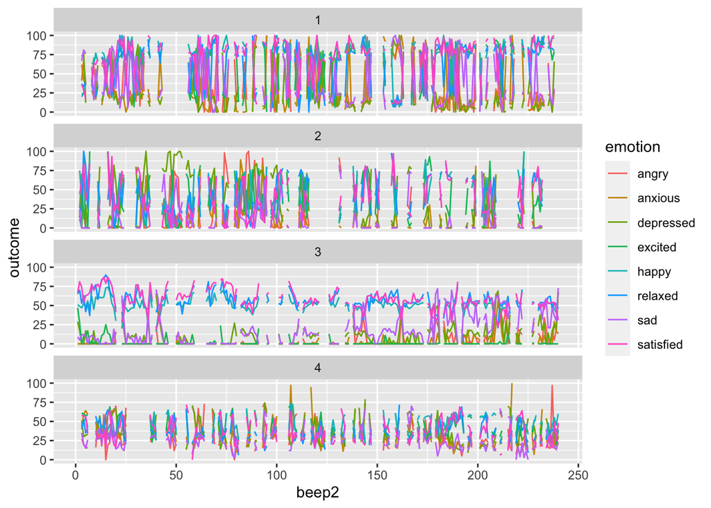

```r
# inspect the first few rows
library(ggplot2)

# restructure the data for ggplot
emotion_data$beep2 <- (emotion_data$dayno - 1) * 6 + emotion_data$beep

ggplot_emotion <- rbind(data.frame(ID = emotion_data$subj_id,
                                 beep2 = emotion_data$beep2,
                                 outcome = emotion_data$happy,
                                 emotion = "happy"),
                      data.frame(ID = emotion_data$subj_id,
                                 beep2 = emotion_data$beep2,
                                 outcome = emotion_data$excited,
                                 emotion = "excited"),
                      data.frame(ID = emotion_data$subj_id,
                                 beep2 = emotion_data$beep2,
                                 outcome = emotion_data$relaxed,
                                 emotion = "relaxed"),
                      data.frame(ID = emotion_data$subj_id,
                                 beep2 = emotion_data$beep2,
                                 outcome = emotion_data$satisfied,
                                 emotion = "satisfied"),
                      data.frame(ID = emotion_data$subj_id,
                                 beep2 = emotion_data$beep2,
                                 outcome = emotion_data$angry,
                                 emotion = "angry"),
                      data.frame(ID = emotion_data$subj_id,
                                 beep2 = emotion_data$beep2,
                                 outcome = emotion_data$anxious,
                                 emotion = "anxious"),
                      data.frame(ID = emotion_data$subj_id,
                                 beep2 = emotion_data$beep2,
                                 outcome = emotion_data$depressed,
                                 emotion = "depressed"),
                      data.frame(ID = emotion_data$subj_id,
                                 beep2 = emotion_data$beep2,
                                 outcome = emotion_data$sad,
                                 emotion = "sad"))

ggplot_emotion$emotion <- as.factor(ggplot_emotion$emotion)

ggplot(ggplot_emotion[ggplot_emotion$ID %in% c(1:5),]) +
  geom_line( mapping = aes(x = beep2, y = outcome, group = emotion, color = emotion)) +
  facet_wrap(vars(ID), ncol = 1)
```

## References

J. Haslbeck, O. Ryan, & F. Dablander (2023). Multimodality and skewness in emotion time series. Emotion, 23(8), 2117–2141. DOI: 10.1037/emo0001218. Z. Rowland & M. Wenzel (2020). Mindfulness and affect-network density: Does mindfulness facilitate disengagement from affective experiences in daily life?. Mindfulness, 11(5), 1253-1266. DOI: 10.1007/s12671-020-01335-4